[figure not shown]

# Week 8 - Support Vector Machines

**Dr. David Elliott**

1. Imballanced Data
2. Multi-Class
3. Strengths and Limitations

# 6. Imballanced Data

Class imbalance is a quite common problem when working with real-world data.

This occours when examples from one class or multiple classes are over-represented in a dataset (e.g. spam filtering, fraud detection, disease screening).

## Dataset Example: Default

**Default:** Customer default records for a credit card company

*"We are interested in predicting whether an individual will default on his or her credit card payment, on the basis of annual income and monthly credit card balance."*$^5$

|  | default | balance | income |
| --- | --- | --- | --- |
| 1 | No | 729.526495 | 44361.62507 |
| 2 | No | 817.180407 | 12106.13470 |
| 3 | No | 1073.549164 | 31767.13895 |
| 4 | No | 529.250605 | 35704.49394 |
| 5 | No | 785.655883 | 38463.49588 |

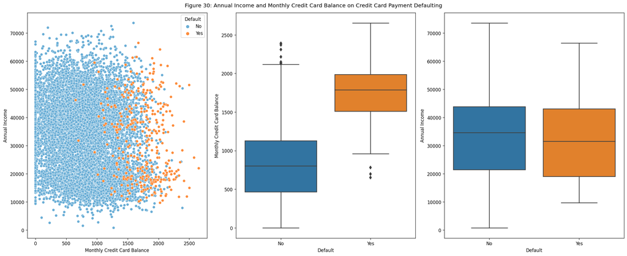

```
Class Distribution (%)
```

```
No     96.67
Yes     3.33
Name: default, dtype: float64
```

```
Best Linear Model Accuracy: 96.56%
```

However, this is not much better than a completely useless model that only predicts "No".

```
Useless Model Accuracy: 96.11%
```

This binary classifier can make two types of errors$^5$:

- Incorrectly assign an individual **who defaults** to the **no default** category.
- Incorrectly assign an individual who **does not default** to the **default** category.

While the overall error rate is low, the error rate among individuals who defaulted is very high.

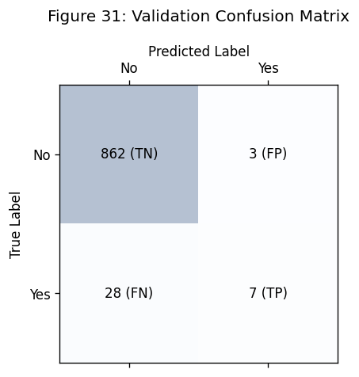

**Error and Accuracy**$^1$

Gives general performance information regarding the number of all correct or false predictions comparative to the total number of predictions for both the positive and negative labels.

$$ \begin{align} ERR &= \frac{FP+FN}{FP+FN+TP+TN} \\ \\ ACC &= 1-ERR \end{align} $$

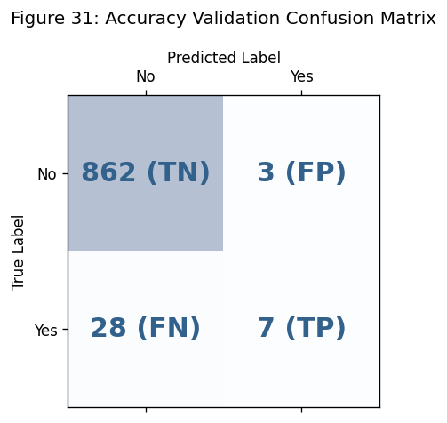

```
Accuracy (ACC): 0.966
```

**Precision (PRE)**$^1$

- Precision gives information on how precise your model is by looking at how many positive predicted labels are actually positive.
- Precision is a good measure to determine, when the costs of a False Positive is high.

$$ PRE = \frac{TP}{TP+FP} $$

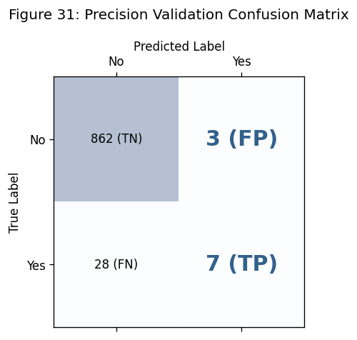

```
Precision (PRE): 0.700
```

**Recall (or True Positive Rate)**$^1$

- Calculates how many of the actual positives our model correctly or incorrectly labelled.
- This is useful when the fraction of correctly or misclassified samples in the positive class are of interest.

$$ REC = \frac{TP}{FN+TP} $$

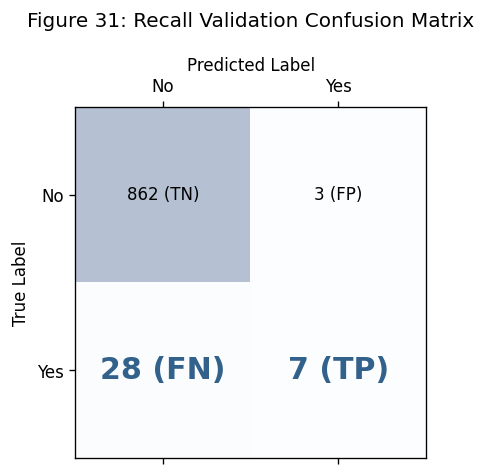

```
Recall (REC): 0.200
```

**F1-score**$^1$

- F1-score is a combination of Recall and Precision.
- It is typically used when there is an **uneven class distribution** due to a large number of True Negatives that you are not as focused on.

$$ F1 = 2\left(\frac{PRE \times REC}{PRE + REC}\right) $$

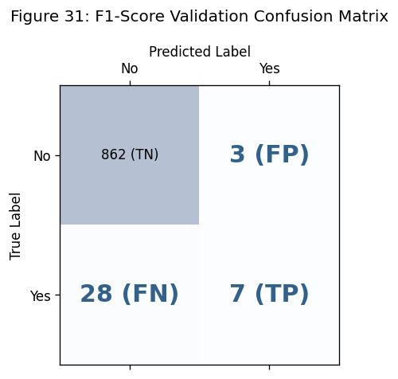

```
F1-Score (F1): 0.311
```

## Potential Reasons for Poor Performance

- Training error rates will usually be lower than test error rates.
- The higher the ratio of parameters $p$ to number of samples $n$, the more we expect this overfitting to play a role.

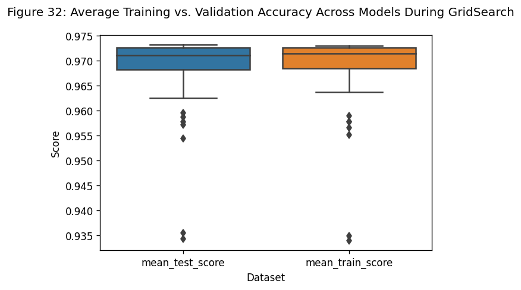

**Optimising for Accuracy**

During hyperparamter cross-validation we are choosing the model with the best **overall accuracy**.

This gives us a model with the smallest possible total number of misclassified observations, irrespective of which class the errors come from$^5$.

ML algorithms typically optimize a reward or cost function computed as a sum over the training examples, the decision rule is likely going to be biased toward the majority class$^9$.

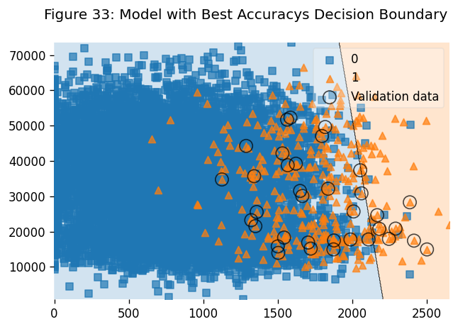

## Potential Solutions for Poor Performance

There are a number of methods available to address imbalances in a dataset, such as:

1. Stratify the k-fold,
2. Weighting the classes in the model during training,
3. Changing the training metric,
4. Resampling the data.

### Stratified k-fold

Some of the folds may not have the same amount of data in, so the validation error we get from models may be a poor estimate of performance.

```
KFold
```

|  | Fold 0 | Fold 1 | Fold 2 | Fold 3 | Fold 4 |
| --- | --- | --- | --- | --- | --- |
| 0 | 1565 | 1572 | 1577 | 1570 | 1560 |
| 1 | 55 | 48 | 43 | 50 | 60 |

```
StratifiedKFold
```

|  | Fold 0 | Fold 1 | Fold 2 | Fold 3 | Fold 4 |
| --- | --- | --- | --- | --- | --- |
| 0 | 1568 | 1569 | 1569 | 1569 | 1569 |
| 1 | 52 | 51 | 51 | 51 | 51 |

### Weights

During model fitting we can assign a larger penalty to wrong predictions on the minority class.

The heuristic used for `class_weight="balanced"` in Scikit-Learn (0.23.1) is:

$$ \frac{n}{Nc \times \sum\limits^n_{i=1}I(y_i \in S)}, $$

where $n$ are the number of samples, $Nc$ the number of classes, $I$ is an indicator function, and $S$ contains the class elements.

### Changing Training/Validation Metric

Changing the metric for what is defined as the *"best model"* can help us prioritise models that make particular errors.

For example, a credit card company might particularly wish to avoid incorrectly classifying an individual who will default, whereas incorrectly classifying an individual who will not default, though still to be avoided, is less problematic.

In this case, **recall** would therefore be a useful metric to use.

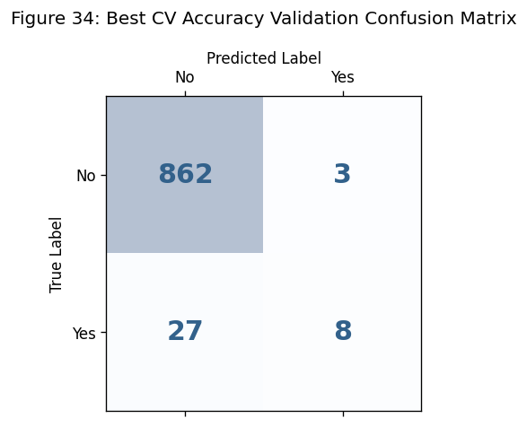

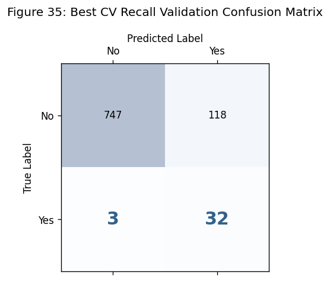

### Resampling

We can change the distribution of the classes in our training data.

#### Under-Sampling

A fast way to balance the data is just to randomly select a subset of the data for each class so they have the number of datapoints found in the smallest class.

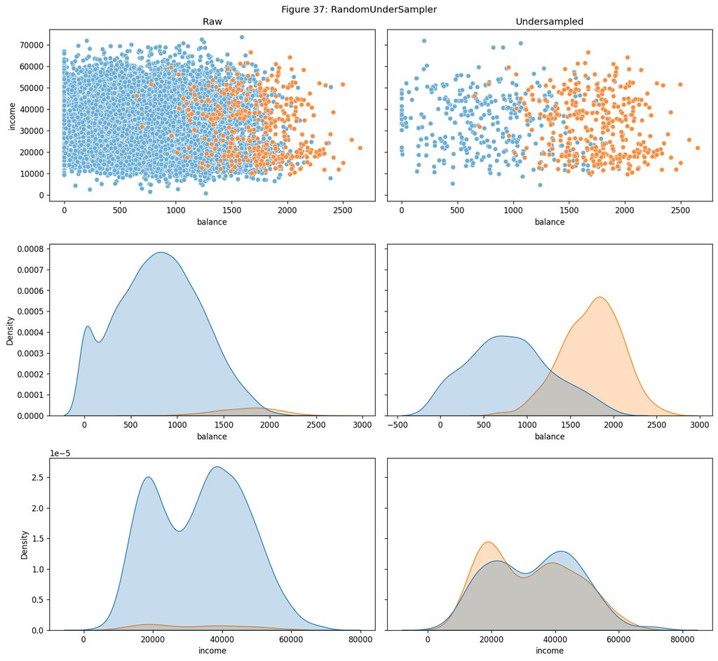

#### Oversampling

Data can be oversampled easily by randomly sampling from minority classes with replacement to duplicate original samples.

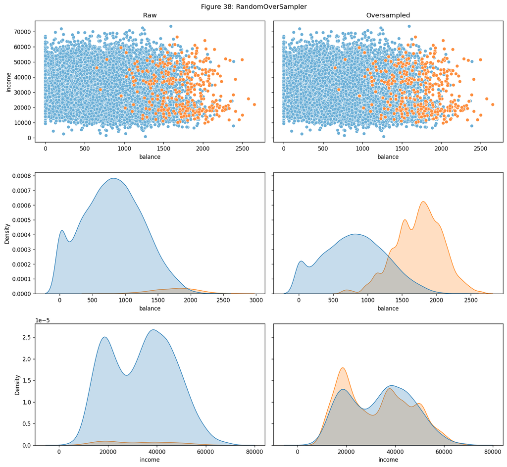

## Best Approach?

There is no one best approach, its typically dependent on the data and the aims for the model.

Below are examples of cross-validation scores for the best models (according to recall) for the different approaches.

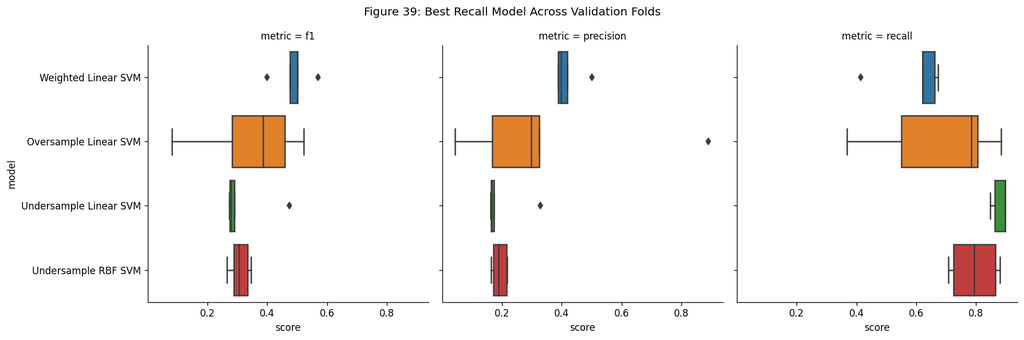

# 7. Multi-Class

Some models (e.g. tree-based classifiers) are inherently multiclass, whereas other machine learning algorithms are able to be extended to multi-class classification using techniques such as the One-versus-Rest or One-versus-One methods<sup>3</sup>.

### One-verses-all (or One-vs-the-rest)

The *One-verses-all* approach is were you train a classifier for each class and select the class from the classifier that outputs the highest score$^3$.

In other terms, if we fit $K$ SVMs, we assign a test observation, $x^*$, to the class for which $\beta_{0k} + \beta_{1k}x^*_1, ...,\beta_{pk}x^*_p$ is largest (the most confident)<sup>5</sup>.

**Advantage:** As each class is fitted against all other classes for each classifier, it is relatively interpretable$^{14}$.

**Disadvantages:** Can result in ambiguious decision regions (e.g. could be class 1 or class 2), and classifiers could suffer from issues of class imballance$^4$.

### OneVsOne

Another strategy is to use a *OneVsOne* approach.

This trains $N \times (N-1) / 2$ classifiers by comparing each class against each other.

When a prediction is made, the class that is selected the most is chosen (*Majority Vote*)$^3$.

**Advantage:** It is useful where algorithms do not scale well with data size (such as SVM), because each training and prediction is only needed to be run on a small subset of the data for each classifer$^{3,14}$.

**Disadvantages:** Can still result in ambiguious decision regions and be computationally expensive$^4$.

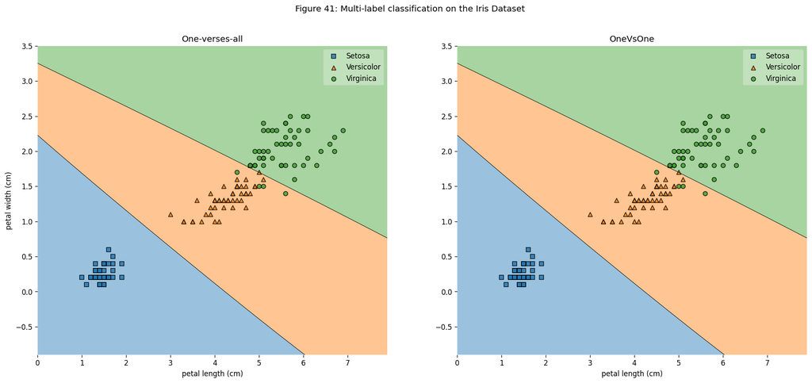

### Multiclass scoring metrics$^9$

`scikit-learn` implements macro and micro averaging methods to extend scoring metrics to multiclass problems.

The *micro-average* is calculated from each TPs, TNs, FPs, and FNs of the system.

For example, the micro-average precision score for a $k$-class system is,

$$ PRE_{micro} = \frac{TP_1+\ldots+TP_K}{TP_1+\ldots+TP_K+FP_1+\ldots+FP_K}. $$

This is useful when we want to weight each instance or prediction equally.

The *macro-average* is the average scores of the different systems:

$$ PRE_{macro} = \frac{PRE_1+\ldots+PRE_K}{K}. $$

This is useful when we want to evaluate the overall performance of a classifier with regard to the most frequent class labels.

# 8. Strengths and Limitations

There are always advantages and disadvantages to using any model on a particular dataset.

## Advantages

1. Kernels allow us to constuct hyperplanes in high dimensional spaces with tractable computation$^6$
   - SVMs allow for complex decision boundaries on both low-dimensional and high-dimensional data (i.e., few and many features).
1. SVMs always converge on the same answer given identical data and hyper-parameters.
1. Kernelized support vector machines perform well on a variety of datasets$^{16}$.
1. By softening the margin using a budget (or cost) parameter (C), SVMs are relatively robust to outliers$^{17}$.
   - Provided hyper-parameters are carefully selected, compared to some ML methods (e.g. Trees), SVM's are less likely to be effected by an over-representation of data in the training phase due to over-parameterization or over-fitting.

## Disadvantages

1. Non-linear SVM's do not scale very well with the number of samples.
   - However, there are batch algorithms which do improve this$^{11}$.
1. SVMs require careful preprocessing of the data$^{16}$.
   - Tree-based models require little or no pre‐processing.
1. SVM models are hard to inspect$^{16}$.
   - It can be difficult to understand why a particular prediction was made.
   - It might be tricky to explain the model to a nonexpert.
1. Discrete data typically presents a problem for SVMs.
   - However, there are alternative implimentations in the litriture to handle discrete data$^{10}$.
1. They are comparatively sensitive to hyperparamters, there can be quite a variation in score depending on setup.
   - The choice of kernel for example can change the results considerably$^{15}$.
1. SVMs only produce predicted class labels (and their *"confidence"*).
   - Obtaining predicted class probabilities requires additional adjustments and computations not covered here.

# References

1. https://scikit-learn.org/stable/datasets/toy_dataset.html
2. Warwick J Nash, Tracy L Sellers, Simon R Talbot, Andrew J Cawthorn and Wes B Ford (1994) "The Population Biology of Abalone (*Haliotis* species) in Tasmania. I. Blacklip Abalone (*H. rubra*) from the North Coast and Islands of Bass Strait", Sea Fisheries Division, Technical Report No. 48 (ISSN 1034-3288)
3. Géron, A. (2017). Hands-on machine learning with Scikit-Learn and TensorFlow: concepts, tools, and techniques to build intelligent systems. " O'Reilly Media, Inc.".
4. Murphy, K. P. (2012). Machine learning: a probabilistic perspective. MIT press.
5. James, Gareth, Daniela Witten, Trevor Hastie, and Robert Tibshirani. An introduction to statistical learning. Vol. 112. New York: springer, 2013.
6. http://contrib.scikit-learn.org/imbalanced-learn/stable/introduction.html
7. https://beckernick.github.io/oversampling-modeling/
8. Mani, I., & Zhang, I. (2003, August). kNN approach to unbalanced data distributions: a case study involving information extraction. In Proceedings of workshop on learning from imbalanced datasets (Vol. 126).
9. Raschka, Sebastian, and Vahid Mirjalili. Python Machine Learning, 2nd Ed. Packt Publishing, 2017.
10. Lemaître, G., Nogueira, F., & Aridas, C. K. (2017). Imbalanced-learn: A python toolbox to tackle the curse of imbalanced datasets in machine learning. The Journal of Machine Learning Research, 18(1), 559-563.
11. Wilson, D. L. (1972). Asymptotic properties of nearest neighbor rules using edited data. IEEE Transactions on Systems, Man, and Cybernetics, (3), 408-421.
12. Tomek, I. (1976). Two modifications of CNN. IEEE Trans. Systems, Man and Cybernetics, 6, 769-772.
13. Batista, G. E., Prati, R. C., & Monard, M. C. (2004). A study of the behavior of several methods for balancing machine learning training data. ACM SIGKDD explorations newsletter, 6(1), 20-29.
14. https://scikit-learn.org/stable/modules/generated/sklearn.multiclass.OneVsRestClassifier.html
15. Burges, C. J. (1998). A tutorial on support vector machines for pattern recognition. Data mining and knowledge discovery, 2(2), 121-167.
16. Müller, A. C., & Guido, S. (2016). Introduction to machine learning with Python: a guide for data scientists. " O'Reilly Media, Inc.".
17. https://bradleyboehmke.github.io/HOML/svm.html